# CFS RT distributions

Hugh Rabagliati

8 June 2016

## b-CFS RT Distribution analyses

In this document, we are going to explore how RTs are distributed in b-CFS experiments, and simulate what happens when we analyze this type of data, assuming it is more like a standard RT. Our test case is the Edinburgh version of a Semantic Violation task developed by Sklar et al. In our version of this task, participants respond when they see a sentence break suppression, indicating if it was above or below fixation. They have 20s to respond. Approx 74 people did this task.

First, let’s see how RTs were distributed

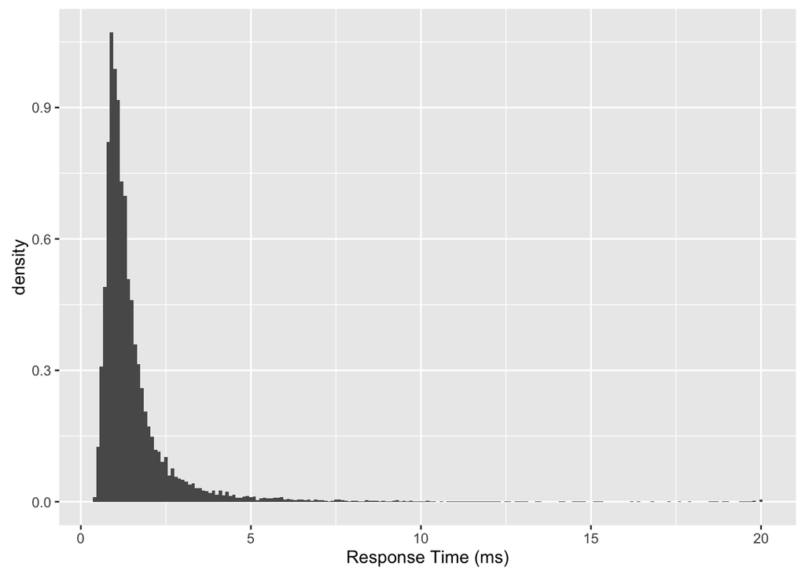

```r
ggplot(edin.sem,aes(x=rt,..density..))+ geom_histogram(binwidth = 0.1)+xlab("Response Time (ms)")
```

You should see that there is a long right tail, but that there are very few instances in that tail after about 7.5s. What sort of distribution fits this best? We have tried four, an ex-Gaussian (three parameters), a log-normal (two parameters), a gamma (two parameters), and a skewed t distribution (four parameters, using Azzalini 1986’s method). They are fit to the data below.

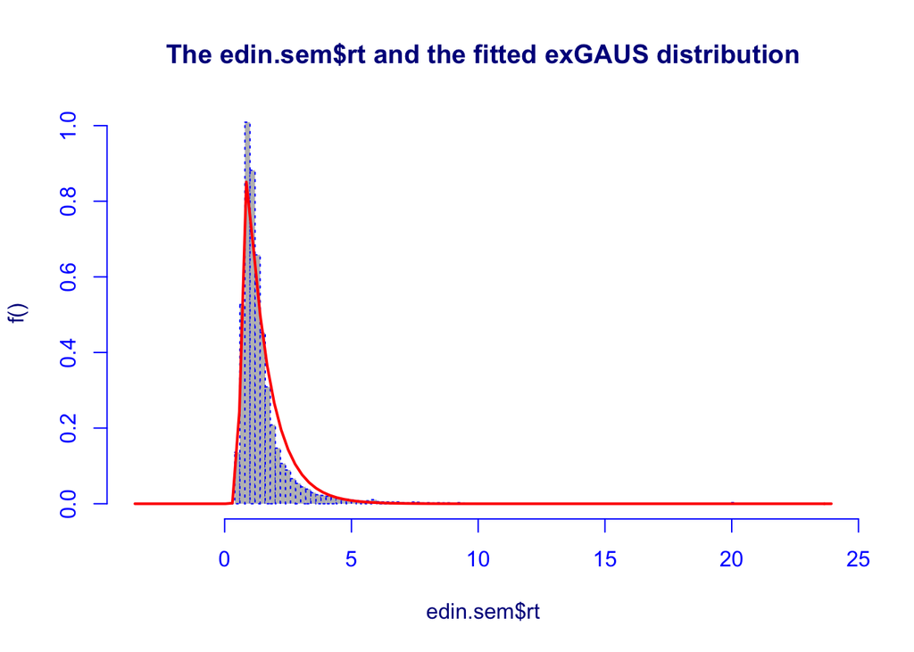

```
##
## Family:  c("exGAUS", "ex-Gaussian")
## Fitting method: "nlminb"
##
## Call:  gamlssML(y = y, family = "exGAUS", formula = edin.sem$rt)
##
## Mu Coefficients:
## [1]  0.6695
## Sigma Coefficients:
## [1]  -2.107
## Nu Coefficients:
## [1]  -0.1253
##
##  Degrees of Freedom for the fit: 3 Residual Deg. of Freedom   20997
## Global Deviance:     41822.9
##             AIC:     41828.9
##             SBC:     41852.7
```

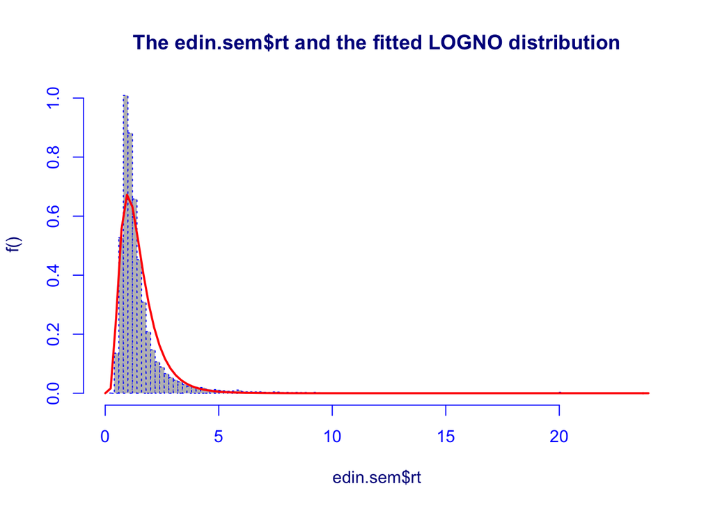

```
##
## Family:  c("LOGNO", "Log Normal")
## Fitting method: "nlminb"
##
## Call:  gamlssML(y = y, family = "LOGNO", formula = edin.sem$rt)
##
## Mu Coefficients:
## [1]  0.2636
## Sigma Coefficients:
## [1]  -0.652
##
##  Degrees of Freedom for the fit: 2 Residual Deg. of Freedom   20998
## Global Deviance:     43279
##             AIC:     43283
##             SBC:     43298.9
```

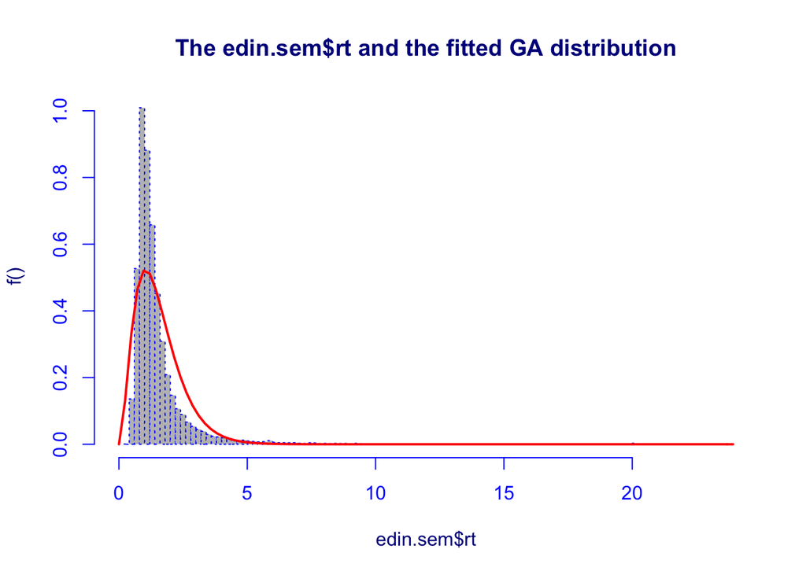

```
##
## Family:  c("GA", "Gamma")
## Fitting method: "nlminb"
##
## Call:  gamlssML(y = y, family = "GA", formula = edin.sem$rt)
##
## Mu Coefficients:
## [1]  0.4394
## Sigma Coefficients:
## [1]  -0.5493
##
##  Degrees of Freedom for the fit: 2 Residual Deg. of Freedom   20998
## Global Deviance:     49909
##             AIC:     49913
##             SBC:     49928.9
```

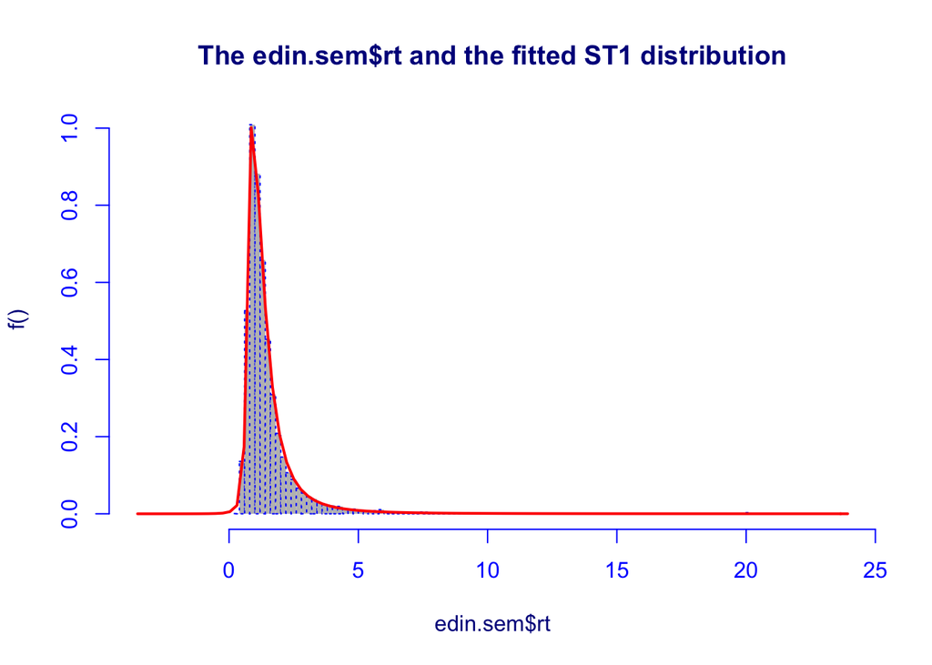

```
##
## Family:  c("ST1", "Skew t (Azzalini type 1)")
## Fitting method: "nlminb"
##
## Call:  gamlssML(y = y, family = "ST1", formula = edin.sem$rt)
##
## Mu Coefficients:
## [1]  0.7079
## Sigma Coefficients:
## [1]  -0.5313
## Nu Coefficients:
## [1]  6.463
## Tau Coefficients:
## [1]  0.6655
##
##  Degrees of Freedom for the fit: 4 Residual Deg. of Freedom   20996
## Global Deviance:     39170.6
##             AIC:     39178.6
##             SBC:     39210.4
```

As you can see, the skewed t provides the cleanest fit, both graphically and in terms of deviance etc. So, let’s try and simulate a bunch of data using that distribution.

```
## [1] 30
## [1] 200
## [1] 400
## [1] 600
## [1] 800
```

```
##   subj rt.p.noexcl log_rt.p.noexcl rt.p.excl1 rt.p.excl2 rt.p.excl3
## 1   30       0.047           0.052      0.045      0.053      0.125
##   rt.p.excl4 rt.p.full
## 1      0.142     0.223
```

```r
subj_range
```

```
##   subj rt.p.noexcl log_rt.p.noexcl rt.p.excl1 rt.p.excl2 rt.p.excl3
## 1   10       0.058           0.061      0.058      0.057      0.074
## 2   30       0.063           0.066      0.063      0.052      0.079
## 3   50       0.051           0.048      0.049      0.051      0.075
## 4   70       0.049           0.048      0.051      0.039      0.070
##   rt.p.excl4 rt.p.full
## 1      0.081     0.081
## 2      0.079     0.079
## 3      0.076     0.076
## 4      0.071     0.071
```

```r
subj_range
```

```
##   subj rt.p.noexcl log_rt.p.noexcl rt.p.excl1 rt.p.excl2 rt.p.excl3
## 1   20       0.037           0.046      0.037      0.038      0.060
## 2   30       0.048           0.056      0.048      0.051      0.074
## 3   70       0.044           0.038      0.043      0.045      0.068
##   rt.p.excl4 rt.p.full
## 1      0.070     0.070
## 2      0.078     0.078
## 3      0.078     0.078
```

Weird skew t

```r
subj_range
```

```
##   subj rt.p.noexcl log_rt.p.noexcl rt.p.excl1 rt.p.excl2 rt.p.excl3
## 1   20      0.0504          0.0507     0.0505     0.0517     0.0756
## 2   30      0.0524          0.0503     0.0519     0.0522     0.0777
## 3   70      0.0463          0.0481     0.0471     0.0508     0.0761
##   rt.p.excl4 rt.p.full
## 1     0.0794    0.0794
## 2     0.0803    0.0803
## 3     0.0805    0.0805
```

Latest skew t with non-fit values

```r
subj_range
```

```
##   subj rt.p.noexcl log_rt.p.noexcl rt.p.excl1 rt.p.excl2 rt.p.excl3
## 1   20      0.0524          0.0496     0.0522     0.0514     0.1048
## 2   30      0.0470          0.0464     0.0478     0.0488     0.1076
## 3   70      0.0468          0.0502     0.0472     0.0464     0.1006
##   rt.p.excl4 rt.p.full
## 1     0.1054    0.1054
## 2     0.1108    0.1108
## 3     0.1014    0.1014
```

What about if we use a simple normal distribution instead?

```
## [1] 20
## [1] 200
## [1] 400
## [1] 600
## [1] 800
## [1] 30
## [1] 200
## [1] 400
## [1] 600
## [1] 800
## [1] 70
## [1] 200
## [1] 400
## [1] 600
## [1] 800
```

Normal distribution with non-fit values

```r
subj_range
```

```
##   subj rt.p.noexcl log_rt.p.noexcl rt.p.excl1 rt.p.excl2 rt.p.excl3
## 1   20      0.0512          0.0504     0.0514     0.0516     0.0848
## 2   30      0.0470          0.0494     0.0472     0.0490     0.0842
## 3   70      0.0514          0.0472     0.0514     0.0566     0.0896
##   rt.p.excl4 rt.p.full
## 1     0.0894    0.0894
## 2     0.0906    0.0906
## 3     0.0922    0.0922
```

# Let’s see with a slightly looser significance criterion

```
## [1] 20
## [1] 30
## [1] 70
```

```r
subj_range
```

```
##   subj rt.p.noexcl log_rt.p.noexcl rt.p.excl1 rt.p.excl2 rt.p.excl3
## 1   20      0.0984          0.1024     0.0982     0.1068     0.1746
## 2   30      0.0966          0.0980     0.0962     0.0956     0.1602
## 3   70      0.0962          0.0988     0.0954     0.0964     0.1798
##   rt.p.excl4 rt.p.full
## 1     0.1760    0.1760
## 2     0.1598    0.1598
## 3     0.1752    0.1752
```

### Let’s see what happens when there is an uncorrelated effect

```
## [1] 20
## [1] 200
## [1] 400
## [1] 30
## [1] 200
## [1] 400
## [1] 70
## [1] 200
## [1] 400
```

```
##   subj rt.p.noexcl log_rt.p.noexcl rt.p.excl1 rt.p.excl2 rt.p.excl3
## 1   20       0.044           0.064      0.044      0.062      0.116
## 2   30       0.040           0.064      0.040      0.048      0.110
## 3   70       0.048           0.066      0.048      0.048      0.124
##   rt.p.excl4 rt.p.full
## 1      0.110     0.110
## 2      0.116     0.116
## 3      0.128     0.128
```

### Let’s see what happens when there is an uncorrelated effect for a normal distr.

```
## [1] 20
## [1] 200
## [1] 400
## [1] 600
## [1] 800
## [1] 30
## [1] 200
## [1] 400
## [1] 600
## [1] 800
## [1] 70
## [1] 200
## [1] 400
## [1] 600
## [1] 800
```

```r
subj_range
```

```
##   subj rt.p.noexcl log_rt.p.noexcl rt.p.excl1 rt.p.excl2 rt.p.excl3
## 1   20      0.1012          0.1046     0.1012     0.1066     0.1036
## 2   30      0.1026          0.0952     0.1024     0.1030     0.0996
## 3   70      0.1024          0.1008     0.1024     0.1026     0.1002
##   rt.p.excl4 rt.p.full
## 1     0.1024    0.1024
## 2     0.1110    0.1110
## 3     0.0950    0.0950
```

```r
subj_range
```

```
##   subj rt.p.noexcl log_rt.p.noexcl rt.p.excl1 rt.p.excl2 rt.p.excl3
## 1   20      0.1012          0.1046     0.1012     0.1066     0.1036
## 2   30      0.1026          0.0952     0.1024     0.1030     0.0996
## 3   70      0.1024          0.1008     0.1024     0.1026     0.1002
##   rt.p.excl4 rt.p.full
## 1     0.1024    0.1024
## 2     0.1110    0.1110
## 3     0.0950    0.0950
```

```r
subj_range
```

```
##   subj rt.p.noexcl log_rt.p.noexcl rt.p.excl1 rt.p.excl2 rt.p.excl3
## 1   20      0.1124          0.1040     0.1124     0.1078     0.1104
## 2   30      0.1032          0.1042     0.1028     0.1008     0.1022
## 3   70      0.1192          0.1152     0.1188     0.1022     0.1168
##   rt.p.excl4 rt.p.full
## 1     0.1046    0.1046
## 2     0.1098    0.1098
## 3     0.1064    0.1064
```

```r
subj_range
```

```
##   subj rt.p.noexcl log_rt.p.noexcl rt.p.excl1 rt.p.excl2 rt.p.excl3
## 1   20      0.1124          0.1040     0.1124     0.1078     0.1104
## 2   30      0.1032          0.1042     0.1028     0.1008     0.1022
## 3   70      0.1192          0.1152     0.1188     0.1022     0.1168
##   rt.p.excl4 rt.p.full
## 1     0.1046    0.1046
## 2     0.1098    0.1098
## 3     0.1064    0.1064
```

## Now let’s try with only 2 conditions

```
## [1] 20
## [1] 200
## [1] 30
## [1] 200
## [1] 70
## [1] 200
```

```
##   subj rt.p.noexcl log_rt.p.noexcl rt.p.excl1 rt.p.excl2 rt.p.excl3
## 1   20        0.05           0.050       0.05      0.050      0.050
## 2   30        0.07           0.085       0.07      0.060      0.065
## 3   70        0.07           0.065       0.07      0.055      0.060
##   rt.p.excl4 rt.p.full
## 1      0.080     0.080
## 2      0.065     0.065
## 3      0.065     0.065
```

```r
subj_range
```

```
##   subj rt.p.noexcl log_rt.p.noexcl rt.p.excl1 rt.p.excl2 rt.p.excl3
## 1   20        0.08            0.12       0.08       0.08       0.16
## 2   30        0.08            0.10       0.08       0.10       0.14
## 3   70        0.16            0.18       0.16       0.14       0.16
##   rt.p.excl4 rt.p.full
## 1       0.10      0.10
## 2       0.10      0.10
## 3       0.14      0.14
```

#### Mix of lognormal and uniform

```
## [1] 20
## [1] 200
## [1] 400
## [1] 600
## [1] 800
## [1] 30
## [1] 200
## [1] 400
## [1] 600
## [1] 800
## [1] 70
## [1] 200
## [1] 400
## [1] 600
## [1] 800
```

```r
subj_range3 <- subj_range
subj_range3
```

```
##   subj rt.p.noexcl log_rt.p.noexcl rt.p.excl1 rt.p.excl2 rt.p.excl3
## 1   20       0.049           0.054      0.055      0.067      0.199
## 2   30       0.041           0.044      0.058      0.058      0.221
## 3   70       0.043           0.044      0.051      0.084      0.224
##   rt.p.excl4 rt.p.full
## 1      0.049     0.055
## 2      0.042     0.058
## 3      0.041     0.050
```

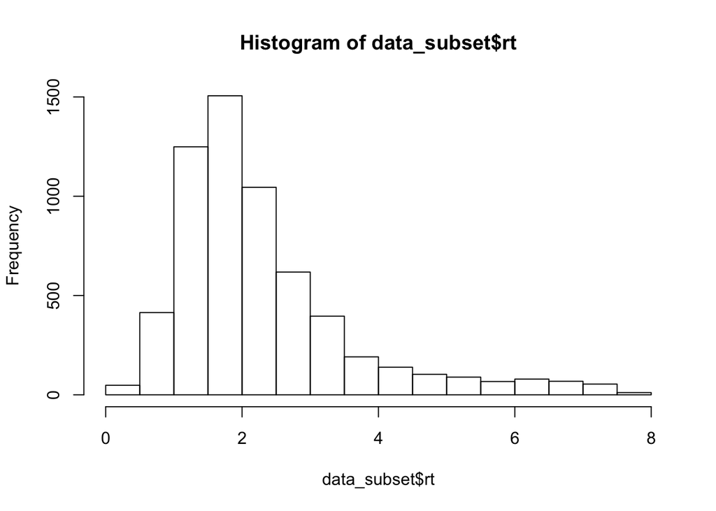

```r
hist(data_subset$rt)
```

#### Mix of gamma and uniform

```
## [1] 20
## [1] 200
## [1] 400
## [1] 600
## [1] 800
## [1] 30
## [1] 200
## [1] 400
## [1] 600
## [1] 800
## [1] 70
## [1] 200
## [1] 400
## [1] 600
## [1] 800
```

```r
subj_range3 <- subj_range
subj_range3
```

```
##   subj rt.p.noexcl log_rt.p.noexcl rt.p.excl1 rt.p.excl2 rt.p.excl3
## 1   20       0.059           0.057      0.059      0.059      0.198
## 2   30       0.054           0.050      0.048      0.046      0.201
## 3   70       0.057           0.051      0.055      0.050      0.242
##   rt.p.excl4 rt.p.full
## 1      0.060     0.059
## 2      0.070     0.048
## 3      0.052     0.054
```

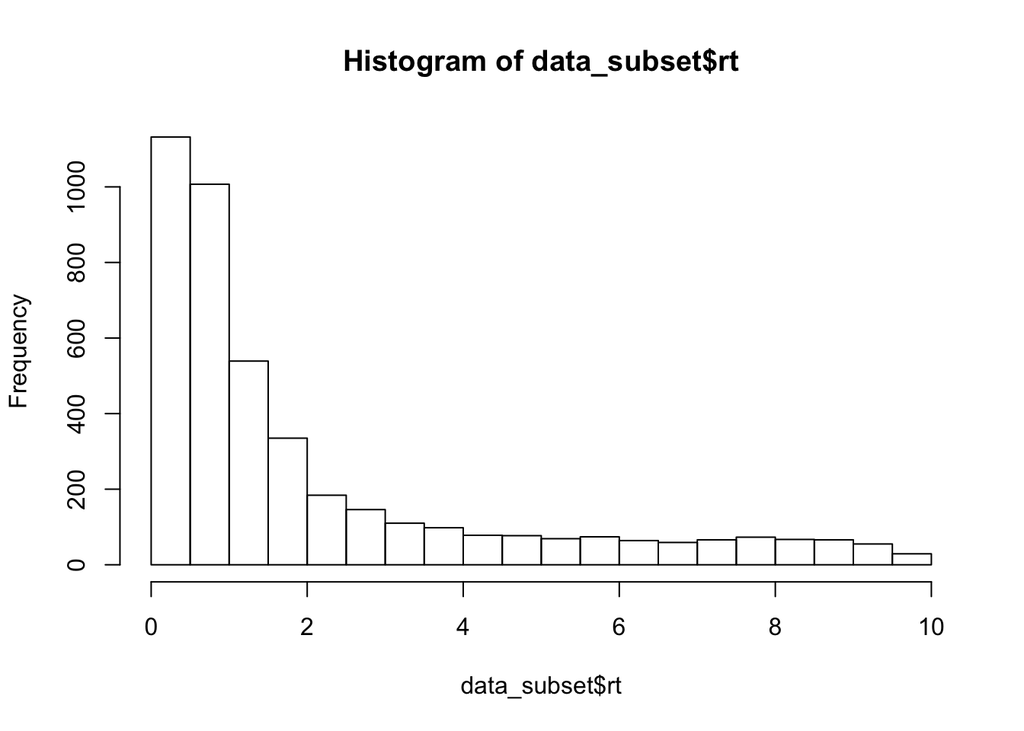

```r
hist(data_subset$rt)
```